```python
%matplotlib inline

# Hiding the warnings
import warnings
warnings.filterwarnings('ignore')
```

# 1) Read the column description and ensure you understand each attribute well

## Importing all the necessary libraries

```python
import pandas as pd
import numpy as np
import matplotlib.pyplot as plt
import seaborn as sns
```

```python
sns.set() # Setting the default seaborn style for all the plots
```

## Reading the data

```python
data = pd.read_csv('Bank_Personal_Loan_Modelling.csv') # Storing the given data into a data frame called as "data"
```

```python
data.head() # Checking the head of the data frame
```

|  | ID | Age | Experience | Income | ZIP Code | Family | CCAvg | Education | Mortgage | Personal Loan | Securities Account | CD Account | Online | CreditCard |
| --- | --- | --- | --- | --- | --- | --- | --- | --- | --- | --- | --- | --- | --- | --- |
| 0 | 1 | 25 | 1 | 49 | 91107 | 4 | 1.6 | 1 | 0 | 0 | 1 | 0 | 0 | 0 |
| 1 | 2 | 45 | 19 | 34 | 90089 | 3 | 1.5 | 1 | 0 | 0 | 1 | 0 | 0 | 0 |
| 2 | 3 | 39 | 15 | 11 | 94720 | 1 | 1.0 | 1 | 0 | 0 | 0 | 0 | 0 | 0 |
| 3 | 4 | 35 | 9 | 100 | 94112 | 1 | 2.7 | 2 | 0 | 0 | 0 | 0 | 0 | 0 |
| 4 | 5 | 35 | 8 | 45 | 91330 | 4 | 1.0 | 2 | 0 | 0 | 0 | 0 | 0 | 1 |

```python
print('The shape before removing the duplicates from the data set is :',data.shape)
data = data.drop_duplicates()
print('The shape after removing the duplicates from the data set is :',data.shape)
```

```
The shape before removing the duplicates from the data set is : (5000, 14)
The shape after removing the duplicates from the data set is : (5000, 14)
```

```python
data.info()
```

```
<class 'pandas.core.frame.DataFrame'>
Int64Index: 5000 entries, 0 to 4999
Data columns (total 14 columns):
 #   Column              Non-Null Count  Dtype
---  ------              --------------  -----
 0   ID                  5000 non-null   int64
 1   Age                 5000 non-null   int64
 2   Experience          5000 non-null   int64
 3   Income              5000 non-null   int64
 4   ZIP Code            5000 non-null   int64
 5   Family              5000 non-null   int64
 6   CCAvg               5000 non-null   float64
 7   Education           5000 non-null   int64
 8   Mortgage            5000 non-null   int64
 9   Personal Loan       5000 non-null   int64
 10  Securities Account  5000 non-null   int64
 11  CD Account          5000 non-null   int64
 12  Online              5000 non-null   int64
 13  CreditCard          5000 non-null   int64
dtypes: float64(1), int64(13)
memory usage: 585.9 KB
```

```python
# Getting a count of number of unique values in each column so as to identify the continuous and discrete variables
data.nunique()
```

```
ID                    5000
Age                     45
Experience              47
Income                 162
ZIP Code               467
Family                   4
CCAvg                  108
Education                3
Mortgage               347
Personal Loan            2
Securities Account       2
CD Account               2
Online                   2
CreditCard               2
dtype: int64
```

```python
# Dropping the ID column
data = data.drop('ID', axis=1)
```

```python
# Checking the shape of the data after removing the 'ID' column
data.shape
```

```
(5000, 13)
```

```python
data.head()
```

|  | Age | Experience | Income | ZIP Code | Family | CCAvg | Education | Mortgage | Personal Loan | Securities Account | CD Account | Online | CreditCard |
| --- | --- | --- | --- | --- | --- | --- | --- | --- | --- | --- | --- | --- | --- |
| 0 | 25 | 1 | 49 | 91107 | 4 | 1.6 | 1 | 0 | 0 | 1 | 0 | 0 | 0 |
| 1 | 45 | 19 | 34 | 90089 | 3 | 1.5 | 1 | 0 | 0 | 1 | 0 | 0 | 0 |
| 2 | 39 | 15 | 11 | 94720 | 1 | 1.0 | 1 | 0 | 0 | 0 | 0 | 0 | 0 |
| 3 | 35 | 9 | 100 | 94112 | 1 | 2.7 | 2 | 0 | 0 | 0 | 0 | 0 | 0 |
| 4 | 35 | 8 | 45 | 91330 | 4 | 1.0 | 2 | 0 | 0 | 0 | 0 | 0 | 1 |

```python
data.nunique()
# Age,Experience,Income,ZIP Code,CCAvg and Mortgage are the continuous variables (predictors)
# Family, Education, Securities Account,CD Account,Online and CreditCard are discrete variable (predictors)
# Personal Loan is a discrete variable (target variable)
```

```
Age                    45
Experience             47
Income                162
ZIP Code              467
Family                  4
CCAvg                 108
Education               3
Mortgage              347
Personal Loan           2
Securities Account      2
CD Account              2
Online                  2
CreditCard              2
dtype: int64
```

```python
# Removing the ZIP Code column from the data frame
data = data.drop('ZIP Code',axis=1)
```

## The five point summary of the continuous variables

```python
data.describe().T
```

|  | count | mean | std | min | 25% | 50% | 75% | max |
| --- | --- | --- | --- | --- | --- | --- | --- | --- |
| Age | 5000.0 | 45.338400 | 11.463166 | 23.0 | 35.0 | 45.0 | 55.0 | 67.0 |
| Experience | 5000.0 | 20.104600 | 11.467954 | -3.0 | 10.0 | 20.0 | 30.0 | 43.0 |
| Income | 5000.0 | 73.774200 | 46.033729 | 8.0 | 39.0 | 64.0 | 98.0 | 224.0 |
| Family | 5000.0 | 2.396400 | 1.147663 | 1.0 | 1.0 | 2.0 | 3.0 | 4.0 |
| CCAvg | 5000.0 | 1.937938 | 1.747659 | 0.0 | 0.7 | 1.5 | 2.5 | 10.0 |
| Education | 5000.0 | 1.881000 | 0.839869 | 1.0 | 1.0 | 2.0 | 3.0 | 3.0 |
| Mortgage | 5000.0 | 56.498800 | 101.713802 | 0.0 | 0.0 | 0.0 | 101.0 | 635.0 |
| Personal Loan | 5000.0 | 0.096000 | 0.294621 | 0.0 | 0.0 | 0.0 | 0.0 | 1.0 |
| Securities Account | 5000.0 | 0.104400 | 0.305809 | 0.0 | 0.0 | 0.0 | 0.0 | 1.0 |
| CD Account | 5000.0 | 0.060400 | 0.238250 | 0.0 | 0.0 | 0.0 | 0.0 | 1.0 |
| Online | 5000.0 | 0.596800 | 0.490589 | 0.0 | 0.0 | 1.0 | 1.0 | 1.0 |
| CreditCard | 5000.0 | 0.294000 | 0.455637 | 0.0 | 0.0 | 0.0 | 1.0 | 1.0 |

```python
data.corr()
```

|  | Age | Experience | Income | Family | CCAvg | Education | Mortgage | Personal Loan | Securities Account | CD Account | Online | CreditCard |
| --- | --- | --- | --- | --- | --- | --- | --- | --- | --- | --- | --- | --- |
| Age | 1.000000 | 0.994215 | -0.055269 | -0.046418 | -0.052012 | 0.041334 | -0.012539 | -0.007726 | -0.000436 | 0.008043 | 0.013702 | 0.007681 |
| Experience | 0.994215 | 1.000000 | -0.046574 | -0.052563 | -0.050077 | 0.013152 | -0.010582 | -0.007413 | -0.001232 | 0.010353 | 0.013898 | 0.008967 |
| Income | -0.055269 | -0.046574 | 1.000000 | -0.157501 | 0.645984 | -0.187524 | 0.206806 | 0.502462 | -0.002616 | 0.169738 | 0.014206 | -0.002385 |
| Family | -0.046418 | -0.052563 | -0.157501 | 1.000000 | -0.109275 | 0.064929 | -0.020445 | 0.061367 | 0.019994 | 0.014110 | 0.010354 | 0.011588 |
| CCAvg | -0.052012 | -0.050077 | 0.645984 | -0.109275 | 1.000000 | -0.136124 | 0.109905 | 0.366889 | 0.015086 | 0.136534 | -0.003611 | -0.006689 |
| Education | 0.041334 | 0.013152 | -0.187524 | 0.064929 | -0.136124 | 1.000000 | -0.033327 | 0.136722 | -0.010812 | 0.013934 | -0.015004 | -0.011014 |
| Mortgage | -0.012539 | -0.010582 | 0.206806 | -0.020445 | 0.109905 | -0.033327 | 1.000000 | 0.142095 | -0.005411 | 0.089311 | -0.005995 | -0.007231 |
| Personal Loan | -0.007726 | -0.007413 | 0.502462 | 0.061367 | 0.366889 | 0.136722 | 0.142095 | 1.000000 | 0.021954 | 0.316355 | 0.006278 | 0.002802 |
| Securities Account | -0.000436 | -0.001232 | -0.002616 | 0.019994 | 0.015086 | -0.010812 | -0.005411 | 0.021954 | 1.000000 | 0.317034 | 0.012627 | -0.015028 |
| CD Account | 0.008043 | 0.010353 | 0.169738 | 0.014110 | 0.136534 | 0.013934 | 0.089311 | 0.316355 | 0.317034 | 1.000000 | 0.175880 | 0.278644 |
| Online | 0.013702 | 0.013898 | 0.014206 | 0.010354 | -0.003611 | -0.015004 | -0.005995 | 0.006278 | 0.012627 | 0.175880 | 1.000000 | 0.004210 |
| CreditCard | 0.007681 | 0.008967 | -0.002385 | 0.011588 | -0.006689 | -0.011014 | -0.007231 | 0.002802 | -0.015028 | 0.278644 | 0.004210 | 1.000000 |

# 2) Distributions of the predictors (continuous)

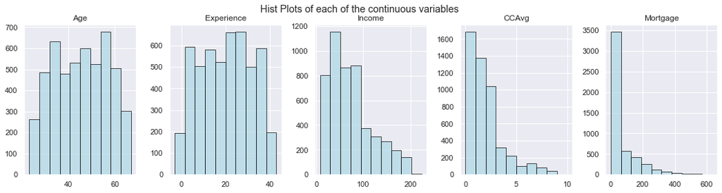

```python
c_cols = ['Age','Experience','Income','CCAvg','Mortgage']
fig,sub = plt.subplots(nrows=1,ncols=len(c_cols),figsize=(18,4))
fig.suptitle('Hist Plots of each of the continuous variables')
for i,num in zip(c_cols,range(len(c_cols))):
    data.hist(i,ax=sub[num],color='lightblue', edgecolor = 'black', alpha = 0.7)
```

### - Age seems to be distributed uniformly

### - Experience seems to be distributed uniformly

### - Income and CCAvg are skewed towards the right side

### - Mortgage is highly skewed towards the right side

```python
from scipy import stats
skews = []
for i in c_cols:
    skew = stats.skew(data[i])
    skews.append(skew)
for i in range(len(skews)) :
    print('The skewness of ',c_cols[i],'is: ',skews[i])
```

```
The skewness of  Age is:  -0.029331878574766698
The skewness of  Experience is:  -0.026316790337654442
The skewness of  Income is:  0.8410861846424931
The skewness of  CCAvg is:  1.5979637637001873
The skewness of  Mortgage is:  2.103371065804789
```

### As seen in the previous step, Income,CCAvg and Mortgage are skewed towards the right hand side.

# 3) Distributions of the predictors (Categorical)

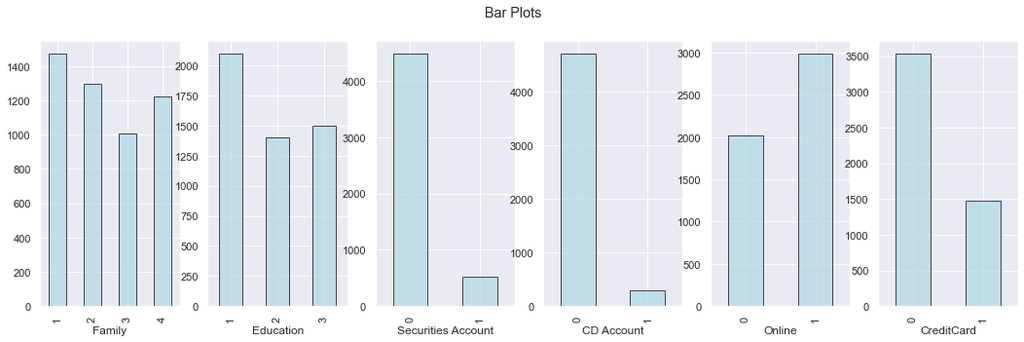

```python
d_cols = ['Family','Education','Securities Account','CD Account','Online','CreditCard']
fig,sub = plt.subplots(nrows=1,ncols=len(d_cols),figsize=(18,5))
fig.suptitle('Bar Plots')
for i,num in zip(d_cols,range(len(d_cols))):
    data.groupby(i).size().plot(kind='bar',ax=sub[num],color='lightblue', edgecolor = 'black', alpha = 0.7)
```

```python
from scipy import stats
skews = []
for i in d_cols:
    skew = stats.skew(data[i])
    skews.append(skew)
for i in range(len(skews)) :
    print('The skewness of ',d_cols[i],'is: ',skews[i])
```

```
The skewness of  Family is:  0.15517409936178264
The skewness of  Education is:  0.22702518198805896
The skewness of  Securities Account is:  2.587491827731683
The skewness of  CD Account is:  3.6906061919698963
The skewness of  Online is:  -0.3946668814543566
The skewness of  CreditCard is:  0.904318051969846
```

## Observing the distribution of the target variable

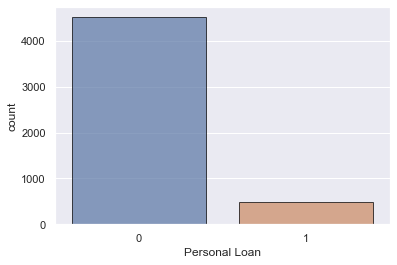

```python
sns.countplot(data['Personal Loan'],edgecolor = 'black', alpha = 0.7)
```

```python
grouped_data = data.groupby('Personal Loan').size()
print(grouped_data)
```

```
Personal Loan
0    4520
1     480
dtype: int64
```

```python
print('The skewness of Personal Loan is :',stats.skew(data['Personal Loan']))
```

```
The skewness of Personal Loan is : 2.74278350529752
```

### - We can see that most of the customers (4520) did not accept the personal loan.

### - We can see that the data is skewed more towards the right.

# --------------------------------------------------------------------------------------------------------------

## Relationship between the target variable and each of the continuous variables(predictors)

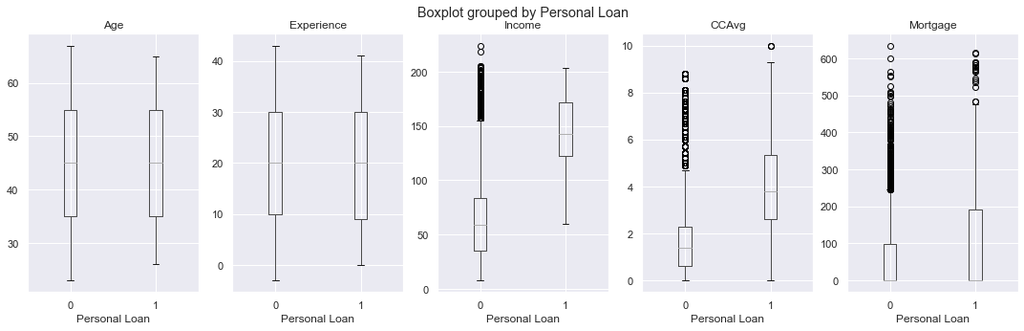

```python
fig,sub = plt.subplots(nrows=1,ncols=len(c_cols),figsize=(18,5))
fig.suptitle('Histograms')
for i,num in zip(c_cols,range(len(c_cols))):
    data.boxplot(i,by='Personal Loan',ax=sub[num])
```

### -We can see that there are outliers present on the higher side for the variables Income,CCAvg and Mortgage.

### -I have replaced only the extreme points among the outliers with a logical value (the max value of that variable for a particular class)

```python
data['CCAvg'].max() # For CCAvg, the maximum value is for class=1
```

```
10.0
```

```python
value = data[data['CCAvg']<10]['CCAvg'].max() # Finding the logical value for replacement
```

```python
data['CCAvg'][data['CCAvg']==10]=value # Replacing the outlier with the logical value
```

```python
data['Income'].max() # For Income, the maximum value is for class=0
```

```
224
```

```python
data[data['Income']<224]['Income'].max() # Finding the second largest
```

```
218
```

```python
value = data[data['Income']<218]['Income'].max() # Finding the logical value
```

```python
data['Income'][data['Income']>=218]=value
```

## Plotting the boxplots after outlier treatment

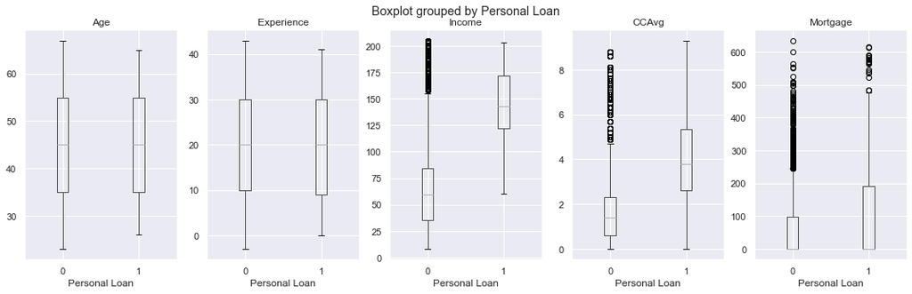

```python
fig,sub = plt.subplots(nrows=1,ncols=len(c_cols),figsize=(18,5))
fig.suptitle('Histograms')
for i,num in zip(c_cols,range(len(c_cols))):
    data.boxplot(i,by='Personal Loan',ax=sub[num])
```

### -The outliers are still present but there are no extreme points as such.

## Feature Selection using statistical tests

## ANOVA test (Categorical vs Continuous)

H0 : There is NO relation between the given variables (p > 0.5)

H1 : There is a relation between the given variables (p <= 0.5)

```python
from scipy.stats import f_oneway
anova = []
for i in c_cols :
    l = data.groupby('Personal Loan')[i].apply(list)
    res = f_oneway(*l)
    anova.append(i +':'+str(res[1]))
for i in anova:
    print(i)
```

```
Age:0.5849592637022671
Experience:0.6002358831617367
Income:1.499094e-318
CCAvg:8.01999216022977e-159
Mortgage:5.7303417216119455e-24
```

### -By looking at the p-values for each of the variables, Age and Experience can be dropped.

```python
data = data.drop(['Age','Experience'],axis=1)
```

```python
data.head()
```

|  | Income | Family | CCAvg | Education | Mortgage | Personal Loan | Securities Account | CD Account | Online | CreditCard |
| --- | --- | --- | --- | --- | --- | --- | --- | --- | --- | --- |
| 0 | 49 | 4 | 1.6 | 1 | 0 | 0 | 1 | 0 | 0 | 0 |
| 1 | 34 | 3 | 1.5 | 1 | 0 | 0 | 1 | 0 | 0 | 0 |
| 2 | 11 | 1 | 1.0 | 1 | 0 | 0 | 0 | 0 | 0 | 0 |
| 3 | 100 | 1 | 2.7 | 2 | 0 | 0 | 0 | 0 | 0 | 0 |
| 4 | 45 | 4 | 1.0 | 2 | 0 | 0 | 0 | 0 | 0 | 1 |

## Chi-Square test (Categorical vs Categorical)

H0 : There is NO relation between the given variables (p > 0.5)

H1 : There is a relation between the given variables (p <= 0.5)

### Visual Representations of relationship between the target variable and the predictor varibales(discrete)

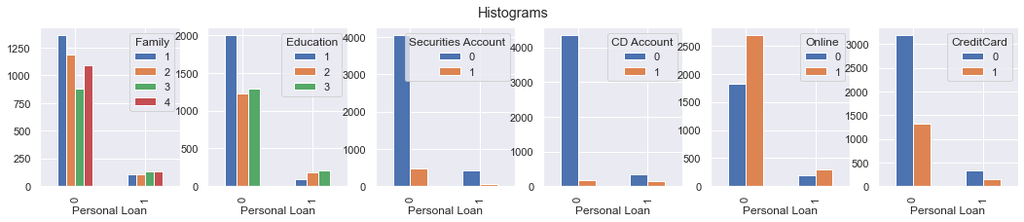

```python
fig,sub = plt.subplots(nrows=1,ncols=len(d_cols),figsize=(18,3))
fig.suptitle('Histograms')
for i,num in zip(d_cols,range(len(d_cols))):
    ctab = pd.crosstab(index=data['Personal Loan'],columns=data[i])
    ctab.plot(kind='bar',ax=sub[num])
```

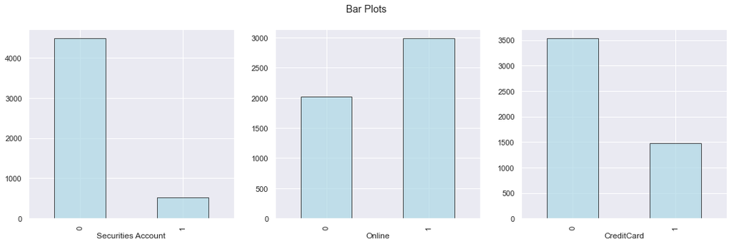

```python
d_cols = ['Securities Account','Online','CreditCard']
fig,sub = plt.subplots(nrows=1,ncols=len(d_cols),figsize=(18,5))
fig.suptitle('Bar Plots')
for i,num in zip(d_cols,range(len(d_cols))):
    data.groupby(i).size().plot(kind='bar',ax=sub[num],color='lightblue', edgecolor = 'black', alpha = 0.7)
```

```python
from scipy.stats import chi2_contingency
chi2 = []
for i in d_cols :
    ctab = pd.crosstab(index=data['Personal Loan'],columns=data[i])
    res = chi2_contingency(ctab)
    chi2.append(i +':'+str(res[1]))
for i in chi2:
    print(i)
```

```
Securities Account:0.14051497326319357
Online:0.6928599643141485
CreditCard:0.8843861223314504
```

```python
data = data.drop(['Securities Account','Online','CreditCard'],axis=1)
```

```python
data.head()
```

|  | Income | Family | CCAvg | Education | Mortgage | Personal Loan | CD Account |
| --- | --- | --- | --- | --- | --- | --- | --- |
| 0 | 49 | 4 | 1.6 | 1 | 0 | 0 | 0 |
| 1 | 34 | 3 | 1.5 | 1 | 0 | 0 | 0 |
| 2 | 11 | 1 | 1.0 | 1 | 0 | 0 | 0 |
| 3 | 100 | 1 | 2.7 | 2 | 0 | 0 | 0 |
| 4 | 45 | 4 | 1.0 | 2 | 0 | 0 | 0 |

## Checking for null values in each of the columns

```python
data.isnull().sum()
```

```
Income           0
Family           0
CCAvg            0
Education        0
Mortgage         0
Personal Loan    0
CD Account       0
dtype: int64
```

```python
processed_data = data
```

```python
processed_data.head()
```

|  | Income | Family | CCAvg | Education | Mortgage | Personal Loan | CD Account |
| --- | --- | --- | --- | --- | --- | --- | --- |
| 0 | 49 | 4 | 1.6 | 1 | 0 | 0 | 0 |
| 1 | 34 | 3 | 1.5 | 1 | 0 | 0 | 0 |
| 2 | 11 | 1 | 1.0 | 1 | 0 | 0 | 0 |
| 3 | 100 | 1 | 2.7 | 2 | 0 | 0 | 0 |
| 4 | 45 | 4 | 1.0 | 2 | 0 | 0 | 0 |

## -The data has been processed and can be used in the models.

# --------------------------------------------------------------------------------------------------------------

# Machine Learning

```python
# Separating the target variable from the predictor variables

X = processed_data.drop('Personal Loan',axis=1).values
y = processed_data[['Personal Loan']].values
y = y.reshape(len(y),1)

print('The shape of X is: ',X.shape)
print('The shape of y is: ',y.shape)
```

```
The shape of X is:  (5000, 6)
The shape of y is:  (5000, 1)
```

# 4) Splitting the data into training and test set in the ratio of 70:30 respectively

```python
from sklearn.model_selection import train_test_split

X_train,X_test,y_train,y_test = train_test_split(X,y,test_size=0.3,random_state=1)

print('The shape of X_train is: ',X_train.shape)
print('The shape of y_train is: ',y_train.shape)
print('The shape of X_test is: ',X_test.shape)
print('The shape of y_test is: ',y_test.shape)
```

```
The shape of X_train is:  (3500, 6)
The shape of y_train is:  (3500, 1)
The shape of X_test is:  (1500, 6)
The shape of y_test is:  (1500, 1)
```

# --- LOGISTIC REGRESSION ---

# 5) Logistic Regression

```python
from sklearn.linear_model import LogisticRegression

model_lgr = LogisticRegression(C=1,penalty='l2',solver='newton-cg')
print(model_lgr)

model_train_lgr = model_lgr.fit(X_train,y_train)
y_pred = model_train_lgr.predict(X_test)

print()
print('The coefficients are: ',model_train_lgr.coef_[0])
print()
print('The intercept is: ',model_train_lgr.intercept_[0])
```

```
LogisticRegression(C=1, solver='newton-cg')

The coefficients are:  [5.32253555e-02 7.14776503e-01 1.53496677e-01 1.67682554e+00
 7.98712877e-04 2.20331519e+00]

The intercept is:  -13.891620746465502
```

# 6) Confusion Matrix and Classification Report

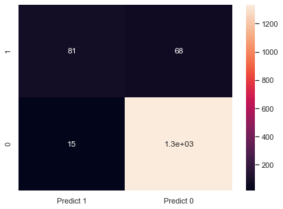

```python
from sklearn import metrics

cm_lgr=metrics.confusion_matrix(y_test, y_pred, labels=[1, 0])

df_cm_lgr = pd.DataFrame(cm_lgr, index = [i for i in ["1","0"]],
                  columns = [i for i in ["Predict 1","Predict 0"]])
plt.figure(figsize = (7,5))
sns.heatmap(df_cm_lgr, annot=True)
```

```python
print(metrics.classification_report(y_test,y_pred))
```

```
              precision    recall  f1-score   support

           0       0.95      0.99      0.97      1351
           1       0.84      0.54      0.66       149

    accuracy                           0.94      1500
   macro avg       0.90      0.77      0.82      1500
weighted avg       0.94      0.94      0.94      1500
```

```python
accuracy_lgr = metrics.classification_report(y_test, y_pred).split()[-2]
accuracy_percentage_lgr = float(accuracy_lgr)*100
```

```python
print('The Accuracy of the Logistic Regression model is :',accuracy_percentage_lgr,'%')
```

```
The Accuracy of the Logistic Regression model is : 94.0 %
```

```python
score = model_lgr.score(X_test,y_test)*100
print('The score of the logistic regression model on the test data is: ',score,'%')
```

```
The score of the logistic regression model on the test data is:  94.46666666666667 %
```

# 5) K-NN

```python
from sklearn.neighbors import KNeighborsClassifier

scores = []

for k in range(1,50) :

    model_knn = KNeighborsClassifier(n_neighbors=k,weights='distance')
    model_train_knn = model_knn.fit(X_train,y_train)

    y_pred = model_train_knn.predict(X_test)

    score = model_train_knn.score(X_test,y_test)
    scores.append(score)
```

```python
k = scores.index(max(scores))-1
print('The value of n_neighbors for which the accuracy is maximum is: ',k)
```

[output not shown]

### Scores for different 'k' values are plotted

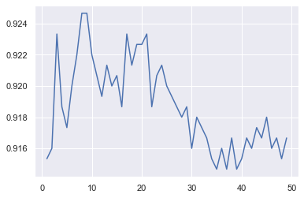

```python
plt.plot(range(1,50),scores)
```

# 6) Confusion Matrix and Classification Report

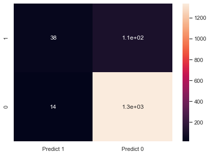

```python
cm_knn=metrics.confusion_matrix(y_test, y_pred, labels=[1, 0])

df_cm_knn = pd.DataFrame(cm_knn, index = [i for i in ["1","0"]],
                  columns = [i for i in ["Predict 1","Predict 0"]])
plt.figure(figsize = (7,5))
sns.heatmap(df_cm_knn, annot=True)
```

```python
print(metrics.classification_report(y_test,y_pred))
```

```
              precision    recall  f1-score   support

           0       0.92      0.99      0.96      1351
           1       0.73      0.26      0.38       149

    accuracy                           0.92      1500
   macro avg       0.83      0.62      0.67      1500
weighted avg       0.90      0.92      0.90      1500
```

```python
accuracy_knn = metrics.classification_report(y_test, y_pred).split()[-2]
accuracy_percentage_knn = float(accuracy_knn)*100
```

```python
print('The Accuracy of the K-NN model is :',accuracy_percentage_knn,'%')
```

[output not shown]

```python
score = model_knn.score(X_test,y_test)*100
print('The score of the K-NN model on the test data is: ',score,'%')
```

```
The score of the K-NN model on the test data is:  91.66666666666666 %
```

# 5) Naïve Bayes

```python
from sklearn.naive_bayes import GaussianNB

model_nb = GaussianNB()
print(model_nb)

NB=model_nb.fit(X_train,y_train)
y_pred=NB.predict(X_test)
```

```
GaussianNB()
```

# 6) Confusion Matrix and Classification Report

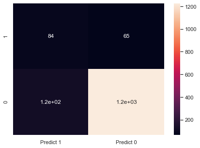

```python
from sklearn import metrics

cm_nb=metrics.confusion_matrix(y_test, y_pred, labels=[1, 0])

df_cm_nb = pd.DataFrame(cm_nb, index = [i for i in ["1","0"]],
                  columns = [i for i in ["Predict 1","Predict 0"]])
plt.figure(figsize = (7,5))
sns.heatmap(df_cm_nb, annot=True)
```

```python
print(metrics.classification_report(y_test,y_pred))
```

```
              precision    recall  f1-score   support

           0       0.95      0.91      0.93      1351
           1       0.40      0.56      0.47       149

    accuracy                           0.87      1500
   macro avg       0.68      0.74      0.70      1500
weighted avg       0.90      0.87      0.88      1500
```

```python
accuracy_nb = metrics.classification_report(y_test, y_pred).split()[-2]
accuracy_percentage_nb = float(accuracy_nb)*100
```

```python
print('The Accuracy of the Naïve Bayes model is :',accuracy_percentage_nb,'%')
```

[output not shown]

```python
score = model_nb.score(X_test,y_test)*100
print('The score of the logistic regression model on the test data is: ',score,'%')
```

[output not shown]

# 7) Which is the best model??

```python
print('The Accuracy of the Logistic Regression model is :',accuracy_percentage_lgr,'%')
print('The Accuracy of the K-NN model is :',accuracy_percentage_knn,'%')
print('The Accuracy of the Naïve Bayes model is :',accuracy_percentage_nb,'%')
```

[output not shown]

# CONCLUSION :

## 1) We can clearly see that the performance of the "Logistic Regression" model is much better than that of the other two models.

## 2) As the given problem is a "binary-classification" problem, Logistic Regression has given us the best result.

# --------------------------------------------------------------------------------------------------------------